# Demonstration

Author

Dusty Turner

Hootenanny Leadership;

I’ve assembled a small visualization that displays a simple model I made for the probability of a tackle for all defensive players.

I’m hoping there’s something here to build on because working on this is tons of fun – but I understand if there isn’t. As I mentioned in the quick hoot last week, if this idea fails, I want it to fail fast. But not, of course, without due diligence.

**Visualization Description**:

- Offense in blue
- Ball is a triangle
- Defense is grey / black

The “blacker” the defensive player, the higher the probability is that the player will make the tackle.

**Quick notes to explain why pass plays do not start at the line of scrimmage**:

- On pass completions, there 5 frames before the ball is caught to 5 frames after the play ends.
- On designed rushes/handoffs, there are 5 frames before the ball is snapped to 5 frames after the play ends.
- On QB scrambles, there are 5 frames before the QB crosses the line of scrimmage to 5 frames after the play ends.

### Runs

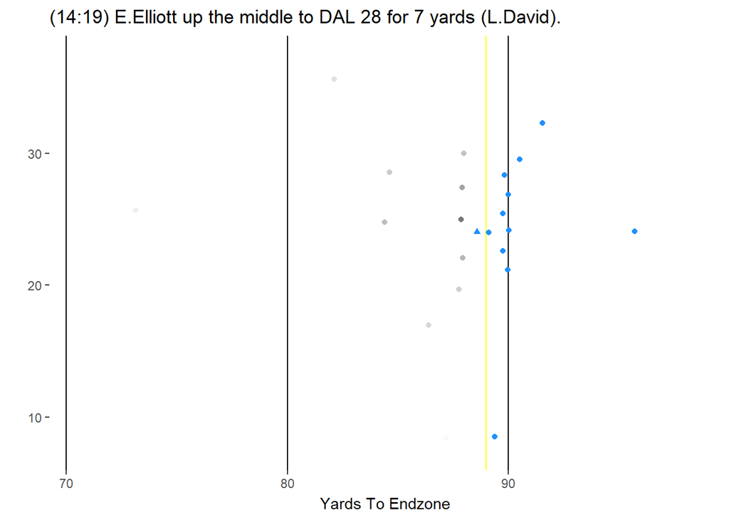

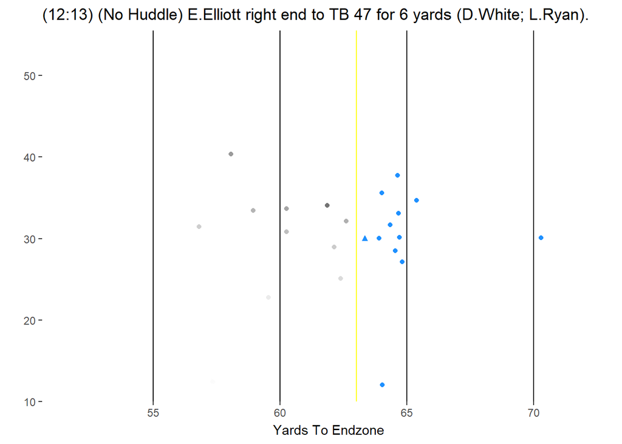

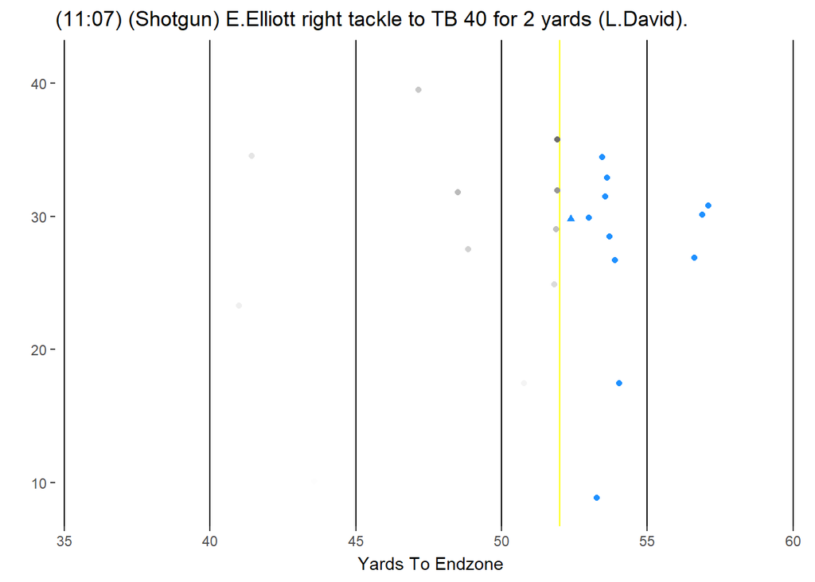

### Passes

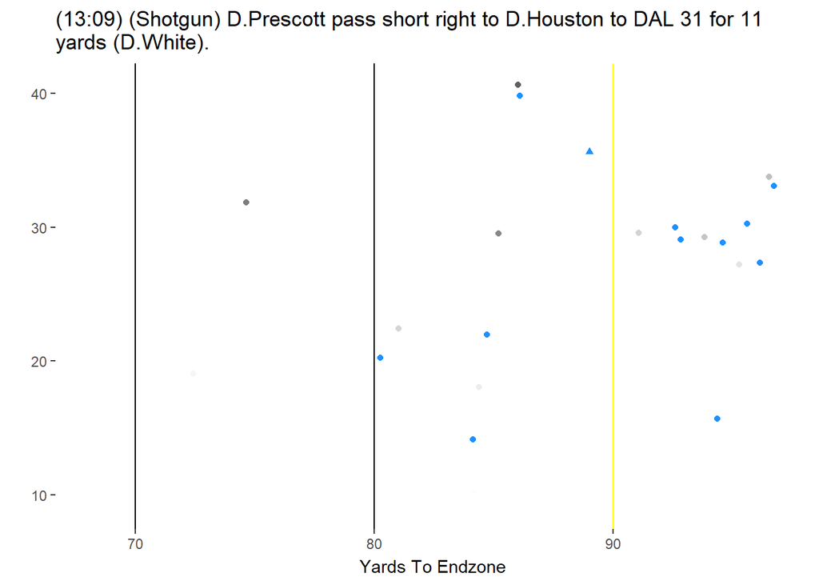

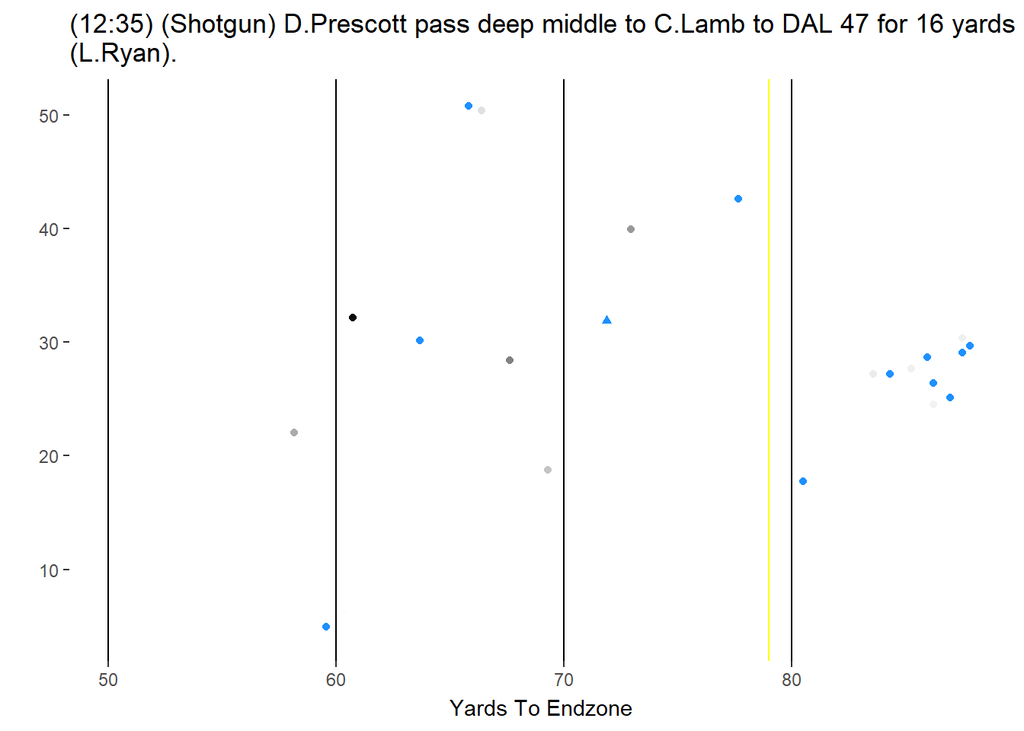

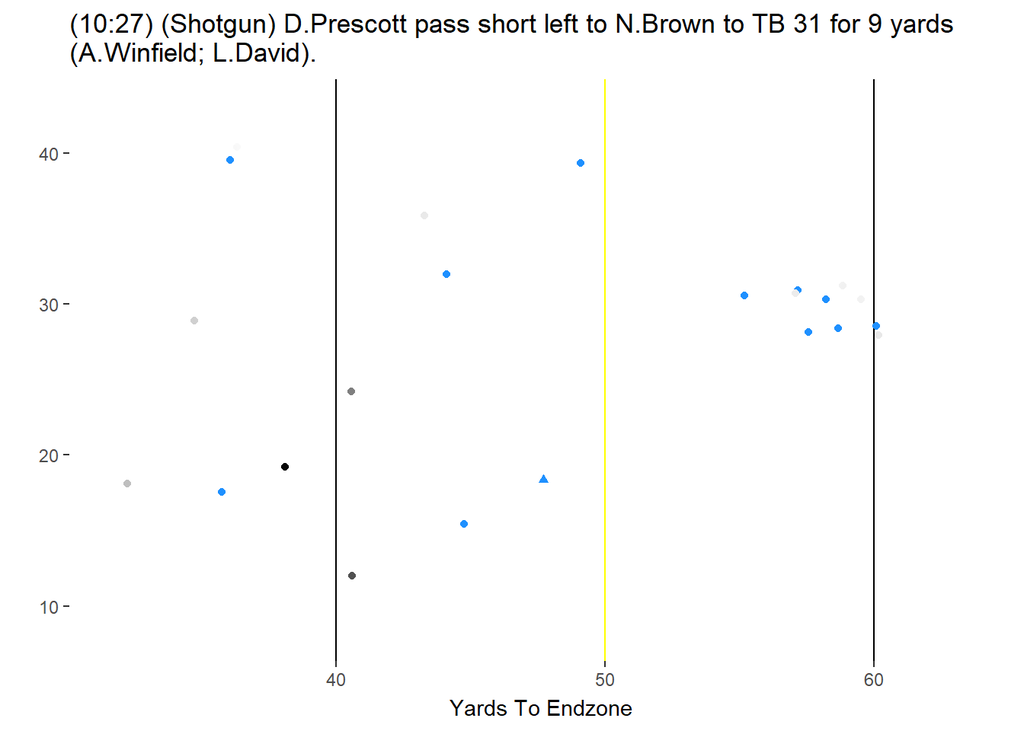